# Non Parametric Methods

Dor Goldenberg

04 May, 2021

# Preface

So far we have discussed parametric methods. In parametric models we assume that the underlying distribution has fixed set of parameters. Usually we are commiting to some distribusion with some mean and variance. Generally speaking, parametric models are more interpretable but more restrictive. In a way the power of ML comes from its power to identify more complex patterns that can’t be found by classic parametric models.

In this exercise we will cover several non-parametric algorithms including regression and clasification trees, random forest, bagging, boosting and KNN. In former exercises the workflow included fitting a model, predicting and metering the predictions. In this exercise we will add two stages: tuning the parameters and interperting the models.

**Question:** Why we are not tuning parameters in OLS or Logistic Regression? How do we estimate these models?

ML models often lack interpretability, it may seem that these models are black boxes. There are multiple reasons why interpretability is [important](https://christophm.github.io/interpretable-ml-book/interpretability-importance.html): from auditing to acceptance and even pure curiosity . From economists point of view it may have even greater importance - we can’t infer causality from a black box process.

**Question:** Can we infer causality from interpretability?

Hence, we are going to cover a few aspects of interpretability in this exercise. We will use the `DALEX` package, and a few methods such as feature importance, variable response, tree surrogate and more.

### Libraries and Data

Load the libraries listed below. You don’t have to use them, it’s up to you.

```r
library(tidyverse)
library(magrittr)
library(tidymodels)
library(caret)
library(DALEX)
library(rpart)
library(rattle)
library(rpart.plot)
library(RColorBrewer)
library(ada)
library(doParallel)
library(pROC)
```

```r
cl <- makePSOCKcluster(5)
registerDoParallel(cl)
```

##### Exercises

1. Load the `heart` dataset from last exercise.
2. For each dataset create train and test sets. Use `set.seed(167)` before your code.

## Models

### Trees

The first family of models we will cover is the trees and forests family. In order to understand these methods we will start in a simple tree model. You should know by now how a tree works. Trees have inherent problem of overfitting and path dependency; we will see methods to deal with these problems.

**Question:** Why simple trees are considered as path dependent? Why simple trees suffer from overfitting?

We will use the `heart` dataset for this exercise. For this part we will use the `rpart` package.

##### Exercises

1. Run the following code. We will use a reduced formula at the beginning in order to allow plotting the trees. For prediction we will use all the variables.

```r
formula_part <- target ~ sex + cp + chol
formula_full <- target ~ .
```

2. Use the `rpart` function to fit a tree model with the reduced formula. Remember to use the argument `method = "class"`. Use the following function to plot the tree: `fancyRpartPlot(your_model, caption = NULL)`.

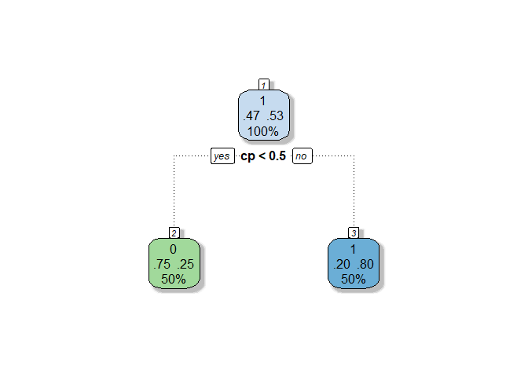

3. The first way to deal with overfitting is by preventing the tree from growing across some point. That criterion can be either by numbers of observations in a split, or by gain from splitting. Use the `rpart` function to fit two tree models. Remember to use the argument `method = "class"`. On the first model use the arguments `minsplit = 2`,`minbucket = 1`. On the second don’t use it. Use the `printcp` to plot the cv outputs for both your models. How many variables was used in each model?
4. Predict: Use the models you fitted and predict the `target` variable in-sample and out of sample (i.e on the train and test sets). Create a confusion matrix for each prediction. Whose model accuracy is best? What can we learn from it?
5. Prune: Another way to deal with overfitting is pruning. Fit the model - prune the model that was fully grown; use cp = 0.03 (complexity parameter). Predict in and out of sample using this model. Create a confusion matrix. What happened to the accuracy? What can we learn from it?

### Forests

After we have seen the basic unit of trees we can go further ahead and deal with forests. For this end we will use `caret`.

### K-Nearest Neighbors (KNN)

KNN is one of the most simple models in ML. It simply utilizes the most close observations for predictions - it can either be used for regression or classification.

#### Cross-Validation

In order to fit our models we will use `caret`. In `caret` you should choose a Cross-Validation method using the `trainControl` function. There are several methods available such as: `repeatedcv`, `oob` (Out-of-Box), `boot` and so on. (check ?trainControl for further information). The basic idea in cross-validation is to use parts of the data to validate the model. We will use a 5-fold CV: it splits the training (!) data fivefold, for each fold it fits the model on the remained 4 folds, and measure the model. In the end it averages the outcome. In `repeatedcv` this process is done several times: the data is randomly shuffled and the model is estimated with k-fold cv; then the data is shuffled again and the model is estimated again with k-fold cv, and so on for the specified times (3 in this case).

##### Exercise

1. Use the `trainControl` function from `caret` to specify cross validation method. Use 5-fold repeated cv with 3 repeats. Assign it to a variable named `fitControl`.

### Fitting a Model

Next, we want to fit some models. We will do this by using the `train` function from `caret`.

##### Exercises

1. Fit 4 models to the data: KNN, bagging, boosting and random forest. Use the `knn`, `ada`, `gbm` and `rf` tags in the “method” argument. Use the variable `fitControl` for the `trControl` argument.
2. Plot: You used the inherent parameters while training the models. For each model use the `ggplot(model_name)` function to plot the parameters against the accuracy.

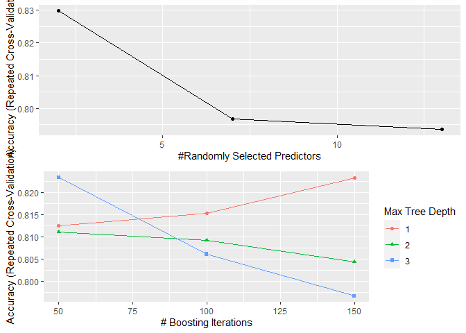

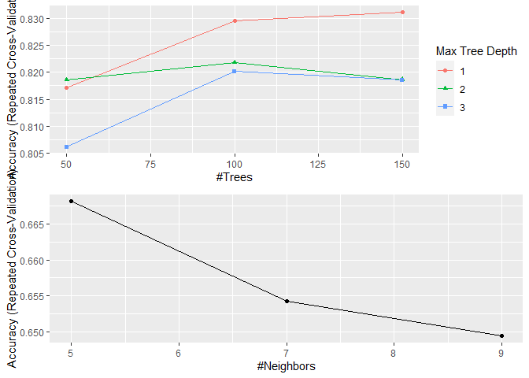

3. User-Defined Grid: Define a grid of gbm grid; use the `expand.grid` function to create a dataframe of parameters for the `gbm` model. The dataframe column names have to match the parameter names in the model. You can find the parameters of each model [here](http://topepo.github.io/caret/available-models.html). Use c(1, 5, 9) for “interaction.depth”, (1:30)*50 for n.trees, 0.1 for “shrinkage” and 20 for n.minobsinnode.
4. Train the model again with your defined grid: Use the `tuneGrid` parameter.
5. Plot the parameters specification against the accuracy both for the user-defined grid and the caret optimized models (the plot from above). You may use `gridExtra::grid.arrange(a,b)` for arranging the plots in a grid. You should get the following graph:

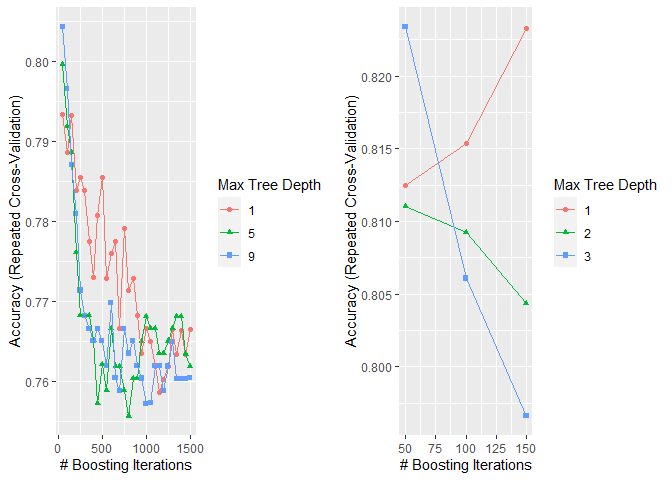

### Interpertability

One of the cons of machine learning models is their lack of interpertability. You can find some materials [here](https://towardsdatascience.com/interpretable-machine-learning-1dec0f2f3e6b) and [here](https://christophm.github.io/interpretable-ml-book/). We would like to know a few things about our models: 1. Performance: What model performs better? We would like to know more than just one number such as rmse or accuracy; we would like to know how the performance ditributed. 2. Variable Importance: Understanding the model includes understanding of its parts - what are the important variables? 3. Partial Dependence: How is the prediction changes with the change in the variable values? 4. Breakdown: How each variable in a model influence the a specific prediction?  
We will use the `DALEX package.

##### Exercises

1. Explainers: Create `explain` object for each model. The format is as follows:  
   `model_explainer <- explain(gbmFit2, label="model_tag", data = your_x, y = your_y)`. Change your data so your y will be numeric.
2. Model Performance: Use the function `model_performance` to create model_performance object for each model. Use the generic `plot` function to plot the outputs - as boxplot and as line graph. You should get the following graphs. Can you interpert them?

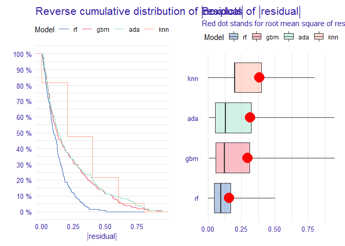

3. Variable Importance: Use the `variable_importance` function to create variable_importance object for each model. Use the generic `plot` function to plot the outputs. You should get the following graphs. Can you interpert them?

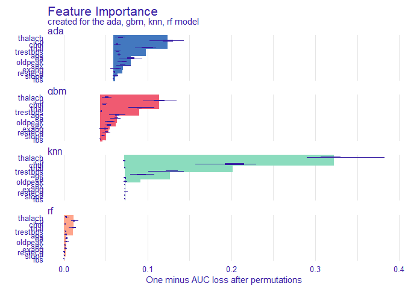

3. Partial Dependence: Use the `variable_effect` function to create partial_dependence_explainer object for each model. Use the generic `plot` function to plot the outputs. You should get the following graphs. Can you interpert them?

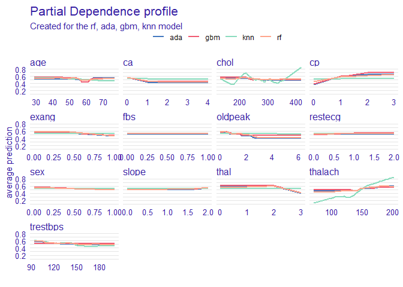

4. Breakdown: Create a dataframe composes of the first row of `heart_train`. Use the `predict_parts_break_down` function to create break_down object for each model. Use the generic `plot` function to plot the outputs. You should get the following graphs. Can you interpert them?

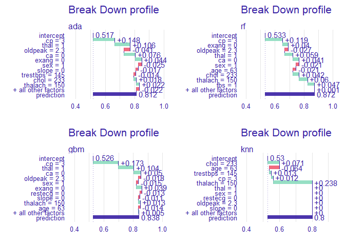

5. Predict: Use the `predict` function to make predictions on the `heart_test` data for each model.
6. ROC: Finally, plot a ROC curve for each model. You should get something like this:

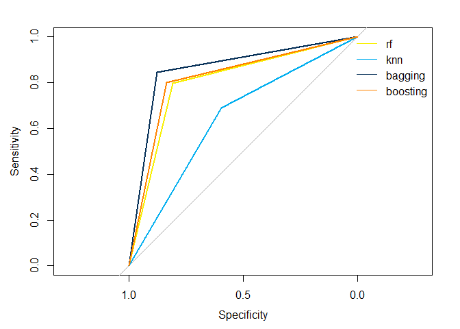

What is the auc of the boosting model? Good Luck!